# Logistic Regression and Classification

# Classification with Logistic Regression

## Low Birth Weight Babies Again

In the last few classes, we’ve used linear regression to predict the birth weight of babies for the purpose of allocating resources. Although linear regression can help us do this, we have other ways to approach this problem.

Logistic regression offers an appealing alternative because it allows us to predict classes instead of values. In this case, we want to predict if a newborn will be classified as low birth weight or not.

## Logistic Regression Basics

### Load the Training Data

```r
train <- read.csv("http://cis241.washjeff-cis.net/low_birth_weight_train.csv", header=TRUE)
str(train)
```

```
## 'data.frame':    189 obs. of  11 variables:
##  $ ID   : int  85 86 87 88 89 91 92 93 94 95 ...
##  $ LOW  : int  0 0 0 0 0 0 0 0 0 0 ...
##  $ AGE  : int  19 33 20 21 18 21 22 17 29 26 ...
##  $ LWT  : int  182 155 105 108 107 124 118 103 123 113 ...
##  $ RACE : int  2 3 1 1 1 3 1 3 1 1 ...
##  $ SMOKE: int  0 0 1 1 1 0 0 0 1 1 ...
##  $ PTL  : int  0 0 0 0 0 0 0 0 0 0 ...
##  $ HT   : int  0 0 0 0 0 0 0 0 0 0 ...
##  $ UI   : int  1 0 0 1 1 0 0 0 0 0 ...
##  $ FTV  : int  0 3 1 2 0 0 1 1 1 0 ...
##  $ BWT  : int  2523 2551 2557 2594 2600 2622 2637 2637 2663 2665 ...
```

### Remove fields to be excluded from analysis

The following code removes all fields except AGE, LWT, RACE, SMOKE, and LOW. LOW is a variable defining our classes: 1 = low birth weight; 0 = not low birth weight

```r
train <- train[,c(2,3,4,5,6)]
str(train)
```

```
## 'data.frame':    189 obs. of  5 variables:
##  $ LOW  : int  0 0 0 0 0 0 0 0 0 0 ...
##  $ AGE  : int  19 33 20 21 18 21 22 17 29 26 ...
##  $ LWT  : int  182 155 105 108 107 124 118 103 123 113 ...
##  $ RACE : int  2 3 1 1 1 3 1 3 1 1 ...
##  $ SMOKE: int  0 0 1 1 1 0 0 0 1 1 ...
```

### Create factors where necessary

Convert the LOW variable to a logical.

```r
train$RACE <- factor(train$RACE)
train$SMOKE <- factor(train$SMOKE)
train$LOW <- as.logical(train$LOW)
str(train)
```

```
## 'data.frame':    189 obs. of  5 variables:
##  $ LOW  : logi  FALSE FALSE FALSE FALSE FALSE FALSE ...
##  $ AGE  : int  19 33 20 21 18 21 22 17 29 26 ...
##  $ LWT  : int  182 155 105 108 107 124 118 103 123 113 ...
##  $ RACE : Factor w/ 3 levels "1","2","3": 2 3 1 1 1 3 1 3 1 1 ...
##  $ SMOKE: Factor w/ 2 levels "0","1": 1 1 2 2 2 1 1 1 2 2 ...
```

## Construct the Model

`glm()` stands for generalized linear model. By specifying the family and link function, we tell R to perform logistic regression.

```r
fm <- glm(LOW ~ AGE + LWT + RACE + SMOKE, data=train, family=binomial(link="logit"))
fm
```

```
##
## Call:  glm(formula = LOW ~ AGE + LWT + RACE + SMOKE, family = binomial(link = "logit"),
##     data = train)
##
## Coefficients:
## (Intercept)          AGE          LWT        RACE2        RACE3
##     0.33245     -0.02248     -0.01253      1.23167      0.94326
##      SMOKE1
##     1.05444
##
## Degrees of Freedom: 188 Total (i.e. Null);  183 Residual
## Null Deviance:       234.7
## Residual Deviance: 214.6     AIC: 226.6
```

```r
#summary(fm)
```

We can take summaries of our models as we did with linear regression. For now, we’ll skip this step.

## Refine the Model

We can perform backwards elimination if we like.

```r
rm <- step(fm, direction = "backward", trace=FALSE )
rm
```

```
##
## Call:  glm(formula = LOW ~ LWT + RACE + SMOKE, family = binomial(link = "logit"),
##     data = train)
##
## Coefficients:
## (Intercept)          LWT        RACE2        RACE3       SMOKE1
##    -0.10922     -0.01326      1.29009      0.97051      1.06001
##
## Degrees of Freedom: 188 Total (i.e. Null);  184 Residual
## Null Deviance:       234.7
## Residual Deviance: 215   AIC: 225
```

```r
#summary(rm)
```

## Predict

### Load our test data

```r
test <- read.csv("http://cis241.washjeff-cis.net/low_birth_weight_test.csv", header=TRUE)
```

### Prepare the test data

```r
test <- test[,2:4]
```

We also need to convert RACE and SMOKE into factors.

```r
test$RACE <- factor(test$RACE)
test$SMOKE <- factor(test$SMOKE)
str(test)
```

```
## 'data.frame':    6 obs. of  3 variables:
##  $ LWT  : int  182 110 125 134 145 75
##  $ RACE : Factor w/ 3 levels "1","2","3": 2 1 3 2 1 2
##  $ SMOKE: Factor w/ 2 levels "0","1": 1 1 2 2 2 1
```

## Make Predictions

Let’s make our predictions.

```r
test$preds_prob <- predict(rm, newdata=test, type="response")
test
```

```
##   LWT RACE SMOKE preds_prob
## 1 182    2     0  0.2257709
## 2 110    1     0  0.1725359
## 3 125    3     1  0.5655870
## 4 134    2     1  0.6139894
## 5 145    1     1  0.2745148
## 6  75    2     0  0.5464692
```

When we pull back our predictions with `type="response"`, we can see the prediction in terms of probability.

```r
test$preds_logit <- predict(rm, newdata=test)
test
```

```
##   LWT RACE SMOKE preds_prob preds_logit
## 1 182    2     0  0.2257709  -1.2323468
## 2 110    1     0  0.1725359  -1.5677606
## 3 125    3     1  0.5655870   0.2638683
## 4 134    2     1  0.6139894   0.4641128
## 5 145    1     1  0.2745148  -0.9718356
## 6  75    2     0  0.5464692   0.1864147
```

When we pull back our predictions without a type definition, we will see the prediction in terms of the log-odds(logit).

For an in-depth explanation of the log-odds and its relationship to probabilities, see the following site: http://www.ats.ucla.edu/stat/mult_pkg/faq/general/odds_ratio.htm

## Picking a class boundary

```r
train$preds_prob <- predict(rm, newdata=train, type="response")
head(train)
```

```
##     LOW AGE LWT RACE SMOKE preds_prob
## 1 FALSE  19 182    2     0  0.2257709
## 2 FALSE  33 155    3     0  0.2325584
## 3 FALSE  20 105    1     1  0.3913937
## 4 FALSE  21 108    1     1  0.3819603
## 5 FALSE  18 107    1     1  0.3850953
## 6 FALSE  21 124    3     0  0.3136999
```

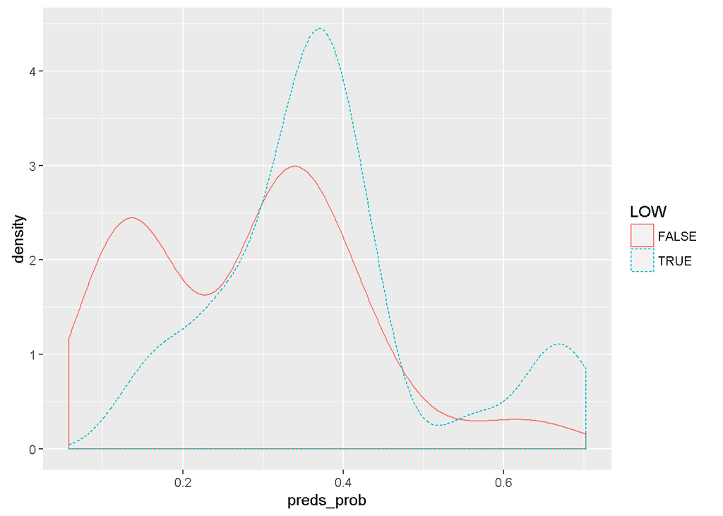

```r
library(ggplot2)
ggplot(train,aes(x=preds_prob,color=LOW, linetype=LOW))+geom_density()
```

Since we have a good deal of overlap, we’ve got our work cut out for us. Let’s start with the common sense idea. Anything with a probability greater than 0.5 will be classified as true.

```r
train$class <- FALSE
train[train$preds_prob>0.5,]$class <- TRUE
head(train)
```

```
##     LOW AGE LWT RACE SMOKE preds_prob class
## 1 FALSE  19 182    2     0  0.2257709 FALSE
## 2 FALSE  33 155    3     0  0.2325584 FALSE
## 3 FALSE  20 105    1     1  0.3913937 FALSE
## 4 FALSE  21 108    1     1  0.3819603 FALSE
## 5 FALSE  18 107    1     1  0.3850953 FALSE
## 6 FALSE  21 124    3     0  0.3136999 FALSE
```

## Evaluating our results

We will evaluate the results of many classifiers. So we’ll want a handy way to review the results of our classifications.

| Confusion Matrix | Condition positive | Condition negative |
| --- | --- | --- |
| **Prediction positive** | True positive(tp) | False positive(fp) |
| **Prediction negative** | False negative(fn) | True negative(tn) |

## Build our confusion matrix

```r
tp <- nrow(train[train$class==TRUE & train$LOW==TRUE,])
fp <- nrow(train[train$class==TRUE & train$LOW==FALSE,])
fn <- nrow(train[train$class==FALSE & train$LOW==TRUE,])
tn <- nrow(train[train$class==FALSE & train$LOW==FALSE,])
```

| Confusion Matrix | Condition positive | Condition negative |
| --- | --- | --- |
| **Prediction positive** | 9 | 8 |
| **Prediction negative** | 50 | 122 |

### Accuracy

Accuracy tells us the percentage of predictions that were correct.

$Accuracy = \dfrac{tp+tn}{tp+tn+fp+fn}$

For our example, the accuracy is:

$Accuracy = \dfrac{9+ 122}{9+122+8+50}$

$Accuracy = 0.6931217$

69.31% of our predictions were correct.

### Precision

How many of our positive predictions (tp) were correct?

$Precision = \dfrac{tp}{tp+fp}$

$Precision = \dfrac{9}{9 + 8}$

$Precision = 0.5294118$

Unfortunately, we are only right about half of the time when we make a positive prediction.

### Recall

How many low birth babies would we actually find with our classifier?

$Recall = \dfrac{tp}{tp+fn}$

$Recall = \dfrac{9}{9+50}$

$Recall = 0.1525424$

Recall exposes our problem: our classifier cannot find many cases which in fact are low birth weight cases.

| Confusion Matrix | Condition positive | Condition negative | Precision |
| --- | --- | --- | --- |
| **Prediction positive** | 9 | 8 | 0.5294118 |
| **Prediction negative** | 50 | 122 |  |
| **Recall** | 0.1525424 |  |  |

## Adjust our cutoff for class boundary if necessary

In this case, we’ll leave it as .5.

```r
test$class <- FALSE
test[test$preds_prob>0.5,]$class <- TRUE
test
```

```
##   LWT RACE SMOKE preds_prob preds_logit class
## 1 182    2     0  0.2257709  -1.2323468 FALSE
## 2 110    1     0  0.1725359  -1.5677606 FALSE
## 3 125    3     1  0.5655870   0.2638683  TRUE
## 4 134    2     1  0.6139894   0.4641128  TRUE
## 5 145    1     1  0.2745148  -0.9718356 FALSE
## 6  75    2     0  0.5464692   0.1864147  TRUE
```